# lernOS Template Leitfaden

## 3.2 Inhaltsverzeichnis und Struktur

Zur einfachen Orientierung für die Lernenden haben alle lernOS Leitfäden die gleiche Grundstruktur ([Blog](https://cogneon.de/2019/04/30/wie-schreibt-man-einen-lernos-guide-einige-vorueberlegungen-zu-einer-anleitung/)). Diese besteht aus den vier Kapiteln Über lernOS, Grundlagen, Lernpfad und Anhang, die im Folgenden beschrieben werden.

- **Kapitel “Über lernOS”:** Das Kapitel “Über lernOS” erklärt die Grundlagen von lernOS (in allen Leitfäden gleich).
- **Kapitel “Grundlagen”:** Das Kapitel “Grundlagen” enthält theoretische Hintergründe und Informationen, die für das Verständnis des Leitfaden-Themas relevant sind. In diesem Kapitel wird viel auf andere verfügbare Quellen und Literatur verwiesen (Hub- oder Kurationsfunktion).
- **Kapitel “Lernpfad”:** Das Kapitel “Lernpfad” enthält die Katas (Übungen) des Leitfadens. Jede Kata wird in einem eigenen Kapitel beschrieben, das maximal zwei Druckseiten lang sein sollte (Sushi-Card-Prinzip). Ein Leitfaden kann mehr als einen Lernpfad enthalten. Wiki-Seite zur [Kata-Dokumentation](https://github.com/cogneon/lernos-core/wiki/How-to-write-a-lernOS-Guide).
- **Kapitel “Anhang”:** Das Kapitel Anhang enthält mindestens die “Änderungshistorie”, oft auch ein Kapitel mit Danksagungen (z.B. um Beitragende zu nennen).

## 3.3 Inhalt und Schreibstil

### 3.3.1 Schreibstil

Damit lernOS Leitfäden möglichst [barrierefrei](https://de.wikipedia.org/wiki/Barrierefreiheit) nutzbar sind, sollte die Sprache so einfach verständlich wie möglich gehalten werden. Anglizismen und Fachbegriff sollten wo möglich vermieden werden. Verwende Fachbegriffe müssen immer in Gemeinsprache erklärt werden. Fachbegriffe müssen wie im [lernOS Glossar](https://github.com/cogneon/lernos-core/blob/master/lernOS%20Glossary/de/lernOS-Glossary-de.md) definiert verwendet werden, um über alle lernOS Leitfäden eine einheitliche Begriffsverwendung zu gewährleisten. Werden in einem Leitfaden sehr viele Fachbegriffe eingeführt, empfiehlt sich ein Unterkapitel Glossar im Anhang des Leitfadens.

Im Kapitel Lernpfad wird eine direkte Ansprache der Lernenden mit “Du” verwendet, um zu aktivieren.

### 3.3.2 Bilder

Ein Bild sagt mehr als 1000 Worte. Daher ist die Bebilderung von Leitfäden sehr sinnvoll. Auch bei Bildern sollten immer Quellen mit CC BY Lizenz verwendet werden. Vorzugsformat für Vektorgrafiken ist [SVG](https://de.wikipedia.org/wiki/Scalable_Vector_Graphics) (als PNG in den Leitfaden eingebunden), für Pixelgrafiken [PNG](https://de.wikipedia.org/wiki/Portable_Network_Graphics). Für die Erstellung und Bearbeitung von SVG-Vektor-Grafiken und den Export in PNG wird [Inkscape](https://inkscape.org) empfohlen, für Pixelgrafiken [Gimp](https://gimp.org).

### 3.3.3 Audio und Video

Da die Produktionskette auch Textdokumente erzeugt, können in lernOS Leitfäden keine Audio- und Video-Inhalte eingebettet werden. Um trotzdem auf Audio- und Videoinhalte zu verweisen, können diese einfach im Text verlinkt werden.

### 3.3.4 Mehrsprachigkeit

lernOS Leitfäden sollten aus Gründen der Barrierefreiheit in möglichst vielen Sprachen vorliegen. Die Übersetzung von Leitfäden kann manuell, aber auch toolgestützt erfolgen. Hierfür wurden bereits folgende Tools verwendet:

- [Deepl](https://de.wikipedia.org/wiki/DeepL) - Online-Übersetzungsdienst
- [Microsoft Word](https://de.wikipedia.org/wiki/Microsoft_Word) - Online-Übersetzungsdienst als Teil von Office 365 (Überprüfen/Übersetzen/Dokument übersetzen)

## 3.4 Markdown Syntax

Die Auszeichnungssprache Markdown lässt verschiedene Stile zu, die oft auch [Markdown Flavors](https://github.com/commonmark/commonmark-spec/wiki/markdown-flavors) genannt werden (z.B. kann man eine Aufzählung mit einem * oder einem - erzeugen). Für lernOS Leitfäden wird [Commonmark](https://commonmark.org) und die [Schreib- und Formatiersyntax von GitHub](https://docs.github.com/en/github/writing-on-github/basic-writing-and-formatting-syntax) als Standard empfohlen.

**Hinweis:** mkdocs verwendet für die Erstellung der Webversion [Python-Markdown](https://python-markdown.github.io), das nicht alle Elemente von Commonmark & Co. unterstützt.

Für die Erstelleung eines lernOS Leitfadens kommt man mit einer überschaubaren Anzahl von Markdown-Auszeichnungen aus:

**Überschriften:**

```
# Überschrift Ebene 1
## Überschrift Ebene 2
### Überschrift Ebene 3
```

**Auszeichnung:**

So kann man **fetten Text** und *kursiven Text* erstellen:

```
**fett**
*kursiv*
```

**Listen:**

Listen können Nummeriert und unnummeriert sein:

```
- Listenpunkt 1
- Listenpunkt 2
```

- Listenpunkt 1
- Listenpunkt 2

Hinweis: Listen mit zwei Ebenen sind in Markdown möglich, werden aber von der Produktionskette nicht unterstützt.

[output not shown]

1. Erstens
2. Zweitens

Hinweis: die Liste muss nicht korrekt durchnummeriert sein. Theoretisch kann jede Zeile der Liste mit 1. beginnen.

**Links:**

So können Links auf Webseiten wie z.B. lernos.org gesetzt werden:

```
[Cogneon](https://lernos.org)
```

Hinweis: Links werden in den produzierten Textdokumenten (z.B. PDF) zu Fußnoten.

**Bilder:**

```
![Alternativtext](./images/bild.png)
```

[figure not shown]

Hinweis: der Pfad zum Bild ist im Markdown immer relativ zum Verzeichnis anzugeben, in dem die Markdown-Datei liegt (i.d.R. Unterverzeichnis *images*).

**Tabellen:**

```
| Kopfzeile|Spalte 2|Spalte 3|
| :--- |:---:|---:|
| linksbündig | zentriert | rechtsbündig |
```

| Kopfzeile | Spalte 2 | Spalte 3 |
| --- | --- | --- |
| linksbündig | zentriert | rechtsbündig |

Hinweis: Tabellen sind in Markdown schwierig zu editieren und wo möglich zu vermeiden.

**Zitate:**

```
> Eine Investition in Wissen bringt immer noch die besten Zinsen.
> (Benjamin Franklin)
```

> Eine Investition in Wissen bringt immer noch die besten Zinsen. (Benjamin Franklin)

**Horizontale Linie:**

```
---
```

## 3.5 Leitfaden Produktionskette

lernOS Leitfäden werden in der Auszeichnungssprache Markdown erstellt und i.d.R. auf GitHub verwaltet. Aus den Markdown-Quellen werden über die lernOS Produktionskette weitere Zielformate wie PDF, Word, E-Book etc. generiert. Diese Generierung kann zentral auf GitHub (noch nicht verfügbar) oder auf dem eigenen Rechner erfolgen.

Generiert man die Zieformate auf dem eigenen Rechner, ist ein Toolset notwendig, das im folgenden beschrieben wird. Wir versuchen wo möglich [Open Source Software](https://de.wikipedia.org/wiki/Open_Source) zu verwenden, die auf allen Plattformen verfügbar sind (Windows, Mac, Linux).

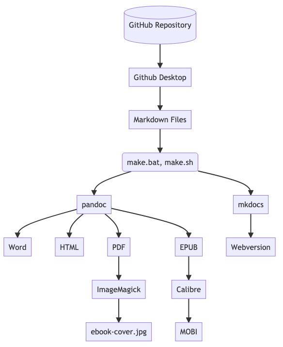

### 3.5.1 lernOS Leitfaden Verzeichnisstruktur

Damit die lernOS Produktionskette funktioniert, müssen die Inhalte des Leitfadens in einem Dateiordner mit folgender Verzeichnisstruktur abgelegt werden (Beispiel für ein Leitfaden mit deutscher und englischer Version, fett sind Ordner- und Dateinamen, dahinter eine kurze Beschreibung):

```
lernos-repository
|– de                                # Sprachversion (nach ISO 639-1)
   |– slides                         # Präsentation (reveal.js)
   |– src                            # Markdown Quelldateien
      |– css                         # Mkdocs Stylesheet Customization
         |– extra.css                # CSS-Datei für Webversion
      |– images                      # Leitfaden Bilder
      |– overrides                   # Mkdocs Stylesheet Customization
      |– stylesheets                 # Mkdocs Stylesheet Customization
      |– 1-0-Grundlagen.md
      |– 2-0-Lernpfad.md
      |– 3-0-Anhang.md
      |– index.md                    # Willkommens-Kapitel (=Startseite)
   |– lernos-repository-de.docx      # Word-Version
   |– lernos-repository-de.epub      # E-Book-Version (epub)
   |– lernos-repository-de.html      # HTML-Version
   |– lernos-repository-de.mobi      # E-Book-Version (mobi)
   |– lernos-repository-de.pdf       # PDF-Version
   |– make.bat                       # Make-Datei (Windows)
   |– make.sh                        # Make-Datei (Mac, Linux)
   |– metadata.yaml                  # Metadaten für Pandoc
   |– mkdocs.yml                     # Steuerdaten für Webversion
|– docs                              # Webversionen (nach Sprache)
   |– de                             # Sprachversion (nach ISO 639-1)
|– README.md                         # Readme für Github
```

**Hinweis:** im Verzeichnis einer Sprachversion liegen zusätzlich alle produzierten Dokumente (z.B. docx, epub, html, mobi, pdf).

**Hinweis:** Für die Benennung der Verzeichnisse für weitere Sprachversionen werden die Kürzel nach [ISO 639-1](https://de.wikipedia.org/wiki/Liste_der_ISO-639-1-Codes) verwendet.

**Hinweis:** Im src-Verzeichnis kann der Leitfaden auch auf 1-2 Unterkapitelebene in einzelne Markdown-Dateien geteilt werden. Jede einzelne Markdown-Datei wird in der Webversion eine einzelne Seite (gut für thematische Kommentierung). Das ist z.B. auch sinnvoll, wenn mehrere Personen gleichzeitig an den Inhalten arbeiten oder die Inhalte in der Webversion auf Kapitelebene kommentierbar sein sollen.

### 3.5.2 lernOS Produktionskette

Für die Erstellung der Zielformate aus den Markdown-Quellen wird ein sog. Makefile verwendet. Auf Windows ist das die Datei *make.bat* (Stabelverarbeitungsdatei), auf Mac und Linux *make.sh* (Shell-Skript).

Ist die Produktionskette auf dem eigenen Rechner richtig eingerichtet, werden durch den Aufruf alle Zielformate automatisch generiert. Je nach Umfang und Geschwindigkeit des eigenen Rechners kann das bis zu einigen Minuten dauern.

**Ablauf der Produktionskette:**

1. Alte Versionen löschen
2. Webversion erstellen
3. Alle Versionen außer E-Book-Version erstellen
4. Cover-Bild aus PDF-Version extrahieren
5. E-Book-Versionen erstellen

**Beispiel make.sh auf Mac:**

```
echo Starting lernOS Guide Generation ...

# Variables
filename="lernOS-Template-Guide-de"
chapters="./src/index.md ./src/1-0-Grundlagen.md ./src/1-1-Grundidee.md ./src/1-2-Lebenszyklus.md ./src/1-3-Inhaltsverzeichnis.md ./src/1-4-Inhalt.md ./src/1-5-Produktionskette.md ./src/2-Lernpfad.md ./src/3-Anhang.md"

# Delete Old Versions
echo Deleting old versions ...
rm -rf $filename.*
rm -rf ../docs/de/*
rm -ff ../docs/de-slides/index.html

# Create Web Version (mkdocs)
echo Creating Web Version ...
mkdocs build

# Create Microsoft Word Version (docx)
echo Creating Word version ...
pandoc metadata.yaml --from markdown -s --resource-path="./src" -F mermaid-filter --number-sections -V lang=de-de -o $filename.docx $chapters

# Create HTML Version (html)
echo Creating HTML version ...
pandoc metadata.yaml --from markdown -s --resource-path="./src" -F mermaid-filter --number-sections -V lang=de-de -o $filename.html $chapters

# Create PDF Version (pdf)
echo Creating PDF version ...
pandoc metadata.yaml --from markdown -s --resource-path="./src" -F mermaid-filter --template lernos --number-sections --toc -V lang=de-de -o $filename.pdf $chapters

# Create eBook Versions (epub, mobi)
echo Creating eBook versions ...
magick -density 300 $filename.pdf[0] src/images/ebook-cover.jpg
mogrify -size 2500x2500 -resize 2500x2500 src/images/ebook-cover.jpg
mogrify -crop 1563x2500+102+0 src/images/ebook-cover.jpg
pandoc metadata.yaml --from markdown -s --resource-path="./src" -F mermaid-filter --epub-cover-image=src/images/ebook-cover.jpg --number-sections --toc -V lang=de-de -o $filename.epub $chapters
ebook-convert $filename.epub $filename.mobi

# Create Slides (revealjs)
# echo Creating Presentation ...
# pandoc metadata.yaml --from markdown -s --resource-path="./src" -t revealjs -V theme=night -s ./slides/index.md -o ../docs/de-slides/index.html
```

### 3.5.3 Ideen für die Erweiterung der lernOS Produktionskette

Wie auch die Leitfäden wird die lernOS Produktionskette kontinuierlich erweitert. Einige Ideen für die Erweiterung:

- **Github Actions:** aktuell ist eine automatisierte Produktionskette mit [GitHub Actions](https://github.com/features/actions) in Vorbereitung.
- **OneNote:** zusätzlich Produktion einer OneNote-Version der Leitfäden (aktuell nur als Begleitdokument, das manuell gepflegt werden muss).
- **Audiobook:** Produktion eines Audiobooks mit Kapitelmarken zum Anhören (z.B. mit [Balbolka](http://www.cross-plus-a.com/balabolka.htm)).
- **Maschinelle Übersetzung:** Nutzung der DeepL API, um Leitfäden in der Produktionskette automatisch übersetzen zu lassen (Mit curl).
- **Kindle Direct Publishing:** Veröffentlichung der E-Book-Versionen auf dem Amazon Marktplatz.
- **TeX:** können wir auf allen Plattformen MiKTeX verwenden?
- **Pandoc Optionen:** alle Optionen und Parameter von pandoc in eine Defaults-Datei auslagern, damit sie nicht in make.sh und make.bat parallel gepflegt werden müssen (-d options.yaml statt metadata.yaml)

## 3.6 Toolset für die Produktionskette

Für die lernOS Produktionskette sind einige Tools auf dem eigenen Rechner oder in der Cloud erforderlich:

1. **Markdown-Editor** - zum Editieren der Inhalte der Leitfäden, die alle in Markdown geschrieben werden (z.B. [Mark Text](https://marktext.app), [Typora](https://typora.io) oder [Atom](https://atom.io)).
2. **Github Desktop** - mit [Github Desktop](https://desktop.github.com) kann das Repository des Leitfadens auf GitHub mit dem lokalen Rechner synchronisiert werden.
3. **Pandoc** - mit [Pandoc](https://pandoc.org) werden die Markdown-Dateien in die Zielformate der lernOS Produktionskette konvertiert.
4. **LaTeX** - um PDF-Dateien erzeugen zu können benötigt Pandoc LaTeX (z.B. [MiKTeX](https://miktex.org) auf Windows oder [MacTeX](https://www.tug.org/mactex) auf dem Mac).
5. **MkDocs** und **Material for MkDocs** - mit [MkDocs](https://www.mkdocs.org) wird die Webversion des Leitfadens erstellt, [Material](https://squidfunk.github.io/mkdocs-material/https://squidfunk.github.io/mkdocs-material) ist das verwendete Theme.
6. **ImageMagick** - mit [ImageMagick](https://imagemagick.org) wird aus der Titelseite der PDF-Version eine Grafik zum Einfügen in die E-Book-Version.
7. **Calibre** - zur Konvertierung der von Pandoc erzeugten E-Book-Version im epub-Format in das mobi-Format wird [Calibre](https://calibre-ebook.com) eingesetzt.

### 3.6.1 Typora

[Typora](https://typora.io/) ist ein Text-Editor zur Bearbeitung von Markdown-Inhalten. Typora ist für lernOS Inhalte der empfohlene Markdown-Editor, weil er plattformübergreifend verfügbar ist und Markdown als echtes WYSIWYG (What You See Is What You Get) anzeigt. Markdown kann man prinzipiell auch mit einfac hen Texteditoren erstellen und bearbeiten, gerade für Einsteiger ist die WYSIWYG-Ansicht aber von Vorteil.

**Hinweis:** Typora war in der Beta-Phase kostenlos und kostet jetzt ca. 15,- Dollar. Um eine kostenfreie Alternative empfehlen zu können, testen wir gerade Mark Text.

[figure not shown]

Typora Screenshot

### 3.6.2 Pandoc

[Pandoc](https://pandoc.org) ist ein Komandozeilen-basierter Text-Konverter, der Markdown in andere Formate konvertieren kann. Beispiel für die Konvertierung von Markdown in Microsoft Word:

```
pandoc dokument.md -o dokument.docx
```

Zu den von Pandoc unterstützten Formaten gehören u.a. Asciidoc, DokuWiki, EPUB (E-Book), HTML, LaTeX, Markdown, MediaWiki, Microsoft PowerPoint, Microsoft Word (docx), OpenOffice/LibreOffice (odt), Reveal.js (Online-Präsentationen), Textile (z.B. für Confluence), uvm.

In der lernOS Produktionskette werden weitere [pandoc-Optionen](https://pandoc.org/MANUAL.html#options)) verwendet:

- metadata.yaml: Metadaten wie Titel, Autor, Version etc.
- -f markdown: Spezifikation des Quellformats (Markdown)
- -s: Generierung von “Standalone” Versionen, d.h. z.B. vollständiges HTML, nicht nur Fragmente
- –resource-path: Pfad, in dem Ressourcen und Bilder gesucht werden
- -F mermaid-filter: Filter, um Mermaid-Syntax in Diagramme zu konvertieren
- –template: Verwendung eines Templates, z.B. bei der PDF-Version
- –number-sections: Nummerierung von Überschriften
- -V lang=de-de: Variable für die Sprache setzen
- -o: Ausgabe-Datei (z.B. Word, PDF)

### 3.6.3 GitHub Desktop

[Github Desktop](https://desktop.github.com) ist ein Client, der GitHub Repositories mit dem lokalen Rechner synchronisieren kann. Somit kann z.B. lokal an Markdown-Inhalten gearbeitet und diese bei Bedarf ins Repository synchronisiert werden. Die Funktionsweise kann man sich ähnlich wie die Synchronisation von Dateien mit Dropbox oder OneDrive vorstellen.

[figure not shown]

Github Desktop Screenshot

### 3.6.4 LaTeX & Co.

LaTeX ist ein Programmpaket, um im TeX-Format geschriebene Textdokumente in Formate wie HTML oder PDF zu konvertieren. In der lernOS Produktionskette wird wird eine LaTeX-Distribution (unter Windows [MiKTeX](https://miktex.org), auf dem Mac [MacTeX](https://tug.org/mactex/https://tug.org/mactex/)) verwendet, um mit pandoc direkt PDF-Dateien generieren zu können. Hierfür ist zusätzlich Ghostscript notwendig.

Als Vorlage für die PDF-Erstellung der lernOS Leitfäden wird das pandoc LaTex Template [Eisvogel](https://github.com/Wandmalfarbe/pandoc-latex-template) verwendet und über die Datei *metadata.yaml* angepasst. Für den Einsatz dieser Vorlage werden bei erstmaligen Verwendung weitere LaTeX-Erweiterungen installiert.

### 3.6.5 MkDocs & Material for MkDocs

[MkDocs](https://www.mkdocs.org/) ist statischer Webseiten Generator, der die responsive Webversion mit Navigation, Suche, Social Links und Kommentarfunktion erzeugt. Als Theme kommt bei der Web-Version der lernOS Leitfäden [Material for MkDocs](https://squidfunk.github.io/mkdocs-material/) zum Einsatz.

[figure not shown]

lernOS Leitfaden Web-Version

### 3.6.6 Disqus

Für die Kommentarfunktion am Ende jeder Seite der Web-Version kommt der Dienst Disqus zum Einsatz. Alle Leitfäden teilen sich das gleiche Disqus-Konto (lernos).

[figure not shown]

Kommentare mit Disqus Screenshot

### 3.6.7 Calibre

[Calibre](https://calibre-ebook.com) ist eine E-Book-Management-Software, die für die Konvertierung der E-Book-Version EPUB in Mobipocket (mobi, z.B. für Kindle Reader und Kindle App) zu erzeugen. Um aus der PDF-Version eines Leitfadens das Titelbild als Grafik zu extrahieren und in die richtige Größe für E-Books zu skalieren kommt das Grafik-Paket [ImageMagick](https://www.imagemagick.org) zum Einsatz.

[figure not shown]

Calibre Screenshot

## 3.7 GitHub

[GitHub](https://github.com) ist ein Internet-Dienst zur verteilten Verwaltung von Software-Entwicklungsprojekten. Mit dem Ansatz “Content as Code” werden die Inhalte der lernOS Leitfäden in Markdown (wie Quelltext einer Software) geschrieben und dann mit der Produktionskette in die Zielformate konvertiert.

Falls im Leitfaden-Team noch keine Erfahrungen mit Git und GitHub vorliegen, hier einige Links zum einarbeiten:

- Git in Wikipedia
- GitHub in Wikipedia
- Video [Was ist GitHub?](https://www.youtube.com/watch?v=3ZlpJHZBbi8) auf YouTube
- Crash-Kurs [Git and GitHub for Beginners](https://www.youtube.com/watch?v=RGOj5yH7evk) auf YouTube

Das GitHub Repository wird nach dem [Git-Flow-Workflow von Atlassian](https://www.atlassian.com/de/git/tutorials/comparing-workflows/gitflow-workflow) verwaltet. Dabei ist im Master-Branch immer die aktuell gültige Version des Leitfadens. Im Develop-Branch werden Änderungen gemacht, die dann für eine neue Version mit einem Pull Request übernommen werden.

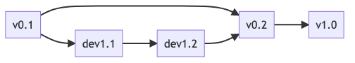

# 4 Lernpfad

Erste Skizze für die 11 Katas im Lernpfad:

**Hinweis:** im Leitfaden-Team kann auch eine Rollenteilung sinnvoll sein: 1-2 Personen kümmern sich um die technische Infrastruktur, der Rest um die Inhalte. Man sollte sich nicht zu lange um die Technik der Produktionskette “drücken” und z.B. in Word, Google Doc & Co. schreiben, da sonst gegen Ende großer Aufwand entsteht, die Inhalte in Markdown zu überführen.

**Bis Boxenstop 1 - Struktur Inhalt und Quellen:**

- **Woche 1 - Zielfindung:** welches Lernziel (Mindset, Skillset, Toolset) soll der Leitfaden für welche Lernende (Zielgruppe) erfüllen? Feedback von Vertretern aus der Zielgruppe einholen.
- **Woche 2 - Ideenfindung Inhaltsverzeichnis:** Ideenfindung, wie das Inhaltsverzeichnis entlang der vier Standard-Kapitel (Über lernOS, Grundlagen, Lernpfad, Anhang) aufgebaut sein könnte. Das kann z.B. in Form einer MindMap (z.B. XMind) erfolgen, in der man sehr flexibel mit Strukturen arbeiten kann.
- **Woche 3 - Inhaltsverzeichnis auf drei Ebenen:** Festlegung der Kapitel-Struktur auf drei (maximal vier) Ebenen. Pro Kapitel können hier bereits erste Stickpunkte zu den Inhalten erfasst werden.
- **Woche 4 - Kuration von Quellen:** Ermittlung von Quellen, die im Grundlagen-Kapitel referenziert werden sollen. Hierbei ist insbesondere auf Absicherung der Quelle in Theorie und/oder Praxis (keine Hypes, Moden etc.), langfristige Verfügbarkeit (z.B. durch institutionellen Träger) und offenen Zugang zu achten.

**Bis Boxenstopp 2 - Technische Infrastruktur:**

- **Woche 5 - Markdown kennenlernen:** Markdown-Editor (Empfehlung Typora) herunterladen und erste Schritte mit der Markdown-Syntax sammeln. Vorteil Typora: damit kann man schon PDF, Word, HTML etc. exportieren, ohne die ganze Produktionskette zu benötigen (Frühes Erfolgserlebnis).
- **Woche 6 - Vorlage von GitHub herunterladen:** aus dem [lernos-template Repository](https://github.com/cogneon/lernos-template) die Leitfaden-Vorlage als ZIP-Datei herunterladen (oben rechts: Code -> Download ZIP) und lokal entpacken. Mit der Verzeichnis- und Datei-Struktur vertraut machen.
- **Woche 7 - Produktionskette installieren:** Toolset für die Produktionskette installieren und Produktionskette zum Laufen bekommen. Einige Änderungen an Metadaten und Inhalten der Vorlage vornehmen und Leitfaden produzieren.
- **Woche 8 - GitHub Synchronisation einrichten:** GitHub Account anlegen, GitHub Desktop installieren und lokales Vorlagen-Verzeichnis mit einem GitHub Repository synchronisieren. Commits und Unterschied Master/Develop-Branch verstehen (s.a. [Gitflow](https://www.atlassian.com/de/git/tutorials/comparing-workflows/gitflow-workflow)).

**Bis Retrospektive - Inhalt:**

- **Woche 9 - Book Sprint** in einem 1- bis 5-tägigen [Book Sprint](https://de.wikipedia.org/wiki/Book_Sprint) werden die Kerninhalte des Leitfadens erstellt. Ziel ist, dass eine Version 0.1 am Ende des Book Sprints in allen Zielformaten auf [GitHub als Release](https://docs.github.com/en/github/administering-a-repository/managing-releases-in-a-repository) zur Verfügung steht und durch die Zielgruppe Feedback gegeben werden kann (z.B. als Issues in GitHub oder durch eine kommentierbare Word-/Google-Doc-Version).
- **Woche 10 - Feedback und Lektorat:** Das Feedback der Zielgruppe wird in die Inhalte eingearbeitet. Die Texte werden korrekturgelesen und Feinheiten verbessert, so dass eine Version 0.2 entsteht.
- **Woche 11 - Go Live!:** Die Version 0.2 wird auf GitHub in Form eines weiteren Release veröffentlicht und auf geeigneten Kanälen an die Zielgruppe kommuniziert. Idealerweise probieren einige Learning Circle den Leitfaden im nächsten Sprint aus, geben Feedback auf Basis dessen dann eine Version 1.0 veröffentlicht werden kann.

# 5 Anhang

## 5.1 Danksagungen

Ein großer Dank an die vielen Projekte und Vorarbeiten, die die Erstellung und Verwaltung von lernOS Leitfäden ermöglichen.

## 5.2 Änderungshistorie

| Version | Bearbeitet von | Beschreibung Änderung | Datum |
| --- | --- | --- | --- |
| 0.1 | Simon Dückert | Erste Version des Template-Repositories | 09.12.2021 |

## 5.3 lernOS Glossar

**A**

- **Aufgabe**
- **Arbeitsumgebung**  
  Nach DIN 33400 ist die Arbeitsumgebung eines Arbeitssystems „das räumliche Umfeld, von dem vor allem physikalische und chemische, aber auch unter anderem biologische (z. B. bakteriologische) Einflüsse auf den Menschen einwirken“. Hierbei wirken Mensch und Arbeitsmittel im Arbeitsablauf am Arbeitsplatz in einer Arbeitsumgebung unter den Bedingungen dieses Arbeitssystems zusammen.

**C**

- **Change Agent**
- **Change Management**

**E**

- **E-Portfolio**  
  Ein E-Portfolio ist eine persönliche, strukturierte und digitale Informationssammlung, die Lernziele und -prozesse im lebenslangen Lernen unterstützt und dabei erworbenes Wissen und Fähigkeiten veranschaulicht.

**F**

- **Formale Organisation**
- **Formales Lernen**  
  Formales Lernen ist das Lernen, das üblicherweise in einer Bildungs- oder Ausbildungseinrichtung stattfindet, in Bezug auf Lernziele, Lernzeit oder Lernförderung strukturiert ist und zur Zertifizierung führt. Formales Lernen ist aus der Sicht des Lernenden zielgerichtet (Europäische Kommission, 2001).
- **Führung** Führung ist die Tätigkeit, Menschen in die Zielfindung einzubinden, motivierende Rahmenbedingungen zu schaffen, Lern- und Entwicklungsprozesse zu unterstützen und die Zielerreichung bei Bedarf zu unterstützen.
- **Führungskraft**  
  Eine Führungskraft ist eine Person in einer Organisation, die mit Aufgaben der Personalführung betraut ist.
- **Führungsstil**  
  Der Führungsstil bezeichnet das langfristig stabile und von der Situation unabhängige Verhalten einer Führungskraft gegenüber Mitarbeitern. Zu den klassischen Führungsstilen nach Levin gehören autoritäre Führung, demokratische Führung und Laissez-faire Führung.

**G**

- **Getting Things Done (GTD)**

**I**

- **Informale Organisation**
- **Informelles Lernen**  
  Informelles Lernen ist das Lernen, das im Alltag, am Arbeitsplatz, im Familienkreis oder in der Freizeit stattfindet. Es ist in Bezug auf Lernziele, Lernzeit oder Lernförderung nicht strukturiert und führt üblicherweise nicht zur Zertifizierung. Informelles Lernen kann zielgerichtet sein, ist jedoch in den meisten Fällen nichtintentional beiläufig (Europäische Kommission, 2001)
- **Infrastruktur**

**K**

- **Kollaboration**  
  Kollaboration ist die Zusammenarbeit von Personen oder Gruppen von Personen (Wikipedia).
- **Kommunikation**  
  Kommunikation ist der Austausch oder die Übertragung von Informationen, die auf verschiedenen Arten (verbal, nonverbal) oder verschiedenen Wegen (Sprechen, Schreiben) stattfinden kann (Wikipedia).
- **Kompetenz**  
  ability to apply knowledge and skills to achieve intended results (ISO 9001:2015).

**L**

- **Lebenslanges Lernen**  
  Lebenslanges Lernen bezeichnet alles Lernen während des gesamten Lebens, das der Verbesserung von Wissen, Qualifikationen und Kompetenzen dient und im Rahmen einer persönlichen, bürgergesell- schaftlichen, sozialen, bzw. beschäftigungsbezogenen Perspektive erfolgt (Europäische Kommission, 2001).
- **Lernen**  
  Lernen ist der absichtliche oder beiläufige Erwerb von Wissen und Fähigkeiten. Lernen führt zu einer Veränderung des Verhaltens, Denkens oder Fühlens auf Basis neuer Erfahrungen oder Einsichten.
- **Lernende Organisation**  
  Eine Lernende Organisation ist eine Organisation, die die Fähigkeit besitzt, Wissen zu generieren, zu akquirieren und zu verteilen und ihr Verhalten auf Basis neuer Erkenntnisse und Einsichten zu verändern.
- **lernOS**  
  lernOS ist ein offenes System für Lebenslanges Lernen und Lernende Organisationen. Es stellt auf den drei Ebenen Individuum, Team und Organisation offene Leitfäden für die kontinuierliche Verbesserung des Lern- und Wissensmanagements bereit.
- **lernOS Canvas**
- **lernOS Rad**
- **Lernpfad**
- **Lernsprint**
- **Lernzirkel**  
  Eine Gruppe von 4-5 Personen in der sich die Mitglieder gegenseitig mit Feedback, Erfahrung, Wissen und Reflexion helfen. Die Circle-Mitglieder treffen sich wöchentlich und folgen dabei einem vorgegebenen Ablauf, der den Lern- und Entwicklungsprozess strukturiert.

**M**

- **Management**  
  Management ist die Koordination der Aktivitäten in einer Organisation mit dem Zweck, die Ziele der Organisation zu erreichen.
- **Mindset**
- **Mission**  
  Die Mission beschreibt, was die Organisation im Tagesgeschäft tut oder tun wird (Business Motivation Model).

**O**

- **Objectives & Key Results (OKR)**
- **Organisation**  
  Eine Organisation besteht aus einer oder oder mehreren Personen (Organisationsmitglieder), die ein gemeinsamer Zweck verbindet und die sich zur Zeckerreichung eine formale Organisationsstruktur geben.

**P**

- **Projekt**
- **Prozess**  
  set of interrelated or interacting activities that use inputs to deliver an intended result (ISO 9001:2015).

**R**

- **Rolle**

**S**

- **Selbstgesteuertes Lernen:**
- **Selbstorganisation**
- **Sinn**
- **Skillset**
- **Sprint**
- **Strategie**

**T**

- **Toolset**
- **True North**  
  Der “wahre Norden” (true north) ist das langfristige Ziel (auch Vision genannt), an dem sich jährliche Ziele und konkrete Verbesserungsaktivitäten orientieren.

**V**

- **Vision**  
  Die Vision beschreibt den zukünftigen Zustand einer Organisation und ihrer Umwelt, unabhängig davon, wie diesser erreicht wird (Business Motivation Model).
- **VUCA** Die Abkürzung steht für volatility, uncertainty, complexity und ambiguity.

**W**

- **Wissen**
- **Wissensmanagement** Wissensmanagement ist die Führung und Gestaltung einer Lernenden Organisation.
- **Working Out Loud**  
  Working Out Loud (WOL) ist eine Arbeitsweise, bei der Arbeitsstände und -ergebnisse offen einsehbar sind (z.B. Wiki, offene Dateiablage) und über den Arbeitsfortschritt offen erzählt wird (z.B. Blog, Microblog).
- **Working Out Loud Lernprogramm**  
  Das Working Out Loud Lernprogramm von John Stepper ist ein 12-wöchiger Lernpfad, mit dem Einsteiger*innen die WOL Arbeitsweise erlernen können.

**Z**

- **Ziel**  
  Result to be achieved (ISO 9001:2015).